# Poznajcie JAGS

## JAGS

Dzisiejszy wpis będzie krótki. Pokażę wam jak zrobić to co w poprzedniej części przy użyciu oprogramowania, które pozwoli nam na tworzenie i estymowanie (przy użyciu MCMC) nawet bardzo skomplikowanych modeli w łatwy sposób. Jest ich kilka, ja przedstawie wam JAGS (*Just Another Gibbs Sampler*). Jest to samodzielne oprogramowanie, które można używać bezpośrednio lub za pomocą języków programowania takich jak **R**, a także graficznego programu statystycznego JASP. Pobrać możecie go tutaj.

### Regresja liniowa

Powtórzmy naszą bayesowską regresję z tym razem przy użyciu JAGS.

```r
library(rjags)
library(coda)
library(MCMCvis)

x = rnorm(100,0,10)
y = 5 + x + rnorm(100,0,10)
data = data.frame(y,x)
```

Musimy zdefiniować kod naszego modelu. JAGS używa dosyć intuicyjnego kodowania BUGS. Model regresji będzie wyglądał tak:

```r
mod = "model {
  # Priors
  a ~ dunif(-1000, 1000)
  b ~ dnorm(0, 100^-1)
  sigma ~ dunif(0.000001,1000)

  # Likelihood
  for (i in 1:length(y)) {
    y[i] ~ dnorm(a + b * x[i], sigma^-2)
  }

}"
```

```r
# Parametry, które chcemy śledzić.
params = c("a","b","sigma")

## Hiperparametry
n.adapt = 100
# Liczba iteracji adaptacji
ni = 3000
# Liczba iteracji "wypalania"
nb = 3000
# Liczba próbek z rozkładu post priori
nt = 1
# liczba łańcuchów
nc = 3


# Inicjacja modelu
jmod = jags.model(file = textConnection(mod), data = data, n.chains = nc, inits = NULL, n.adapt = n.adapt)
# Wypalanie
update(jmod, n.iter=nb, by=1)

# Losowanie próbek z rozkładu post priori
post = coda.samples(jmod, params, n.iter = ni, thin = nt)
```

Zauważcie, że Jags miał tylko 3000 iteracji wypalania, podczas gdy mój kod z poprzedniej części potrzebował ponad 16 razy więcej. JAGS używa kombinacji różnych agorytmów MCMC, ponado dokonuje za nas tunningu hiperparametrów (takich jak na przykład step size w Metropolis-Hasting). Dlatego, oprócz wypalania i losowania, mamy jeszcze adaptację. Obejrzmy sobie rozkłady *post priori*:

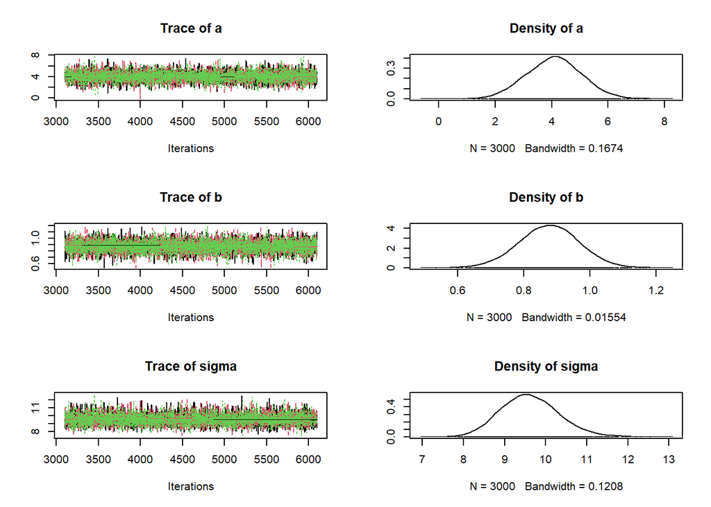

```r
plot(post)
```

Policzmy statystyki:

```r
summary(post)
```

```
##
## Iterations = 3101:6100
## Thinning interval = 1
## Number of chains = 3
## Sample size per chain = 3000
##
## 1. Empirical mean and standard deviation for each variable,
##    plus standard error of the mean:
##
##         Mean     SD  Naive SE Time-series SE
## a     4.0805 0.9773 0.0103017      0.0109534
## b     0.8757 0.0916 0.0009656      0.0009794
## sigma 9.6144 0.7042 0.0074224      0.0077977
##
## 2. Quantiles for each variable:
##
##         2.5%    25%    50%    75%  97.5%
## a     2.1645 3.4231 4.0906  4.731  6.008
## b     0.6945 0.8156 0.8766  0.937  1.053
## sigma 8.3252 9.1231 9.5842 10.068 11.099
```

A także sprawdźmy czy łańcuchy się zbiegły:

```r
gelman.diag(post)
```

```
## Potential scale reduction factors:
##
##       Point est. Upper C.I.
## a              1          1
## b              1          1
## sigma          1          1
##
## Multivariate psrf
##
## 1
```

Statystyka Gelmana-Rubina wskazuje, że łańcuchy się zbiegły. Sprawdźmy jeszcze czy aby na pewno stastystyka nie osiągneła takich wartości przez przypadek.

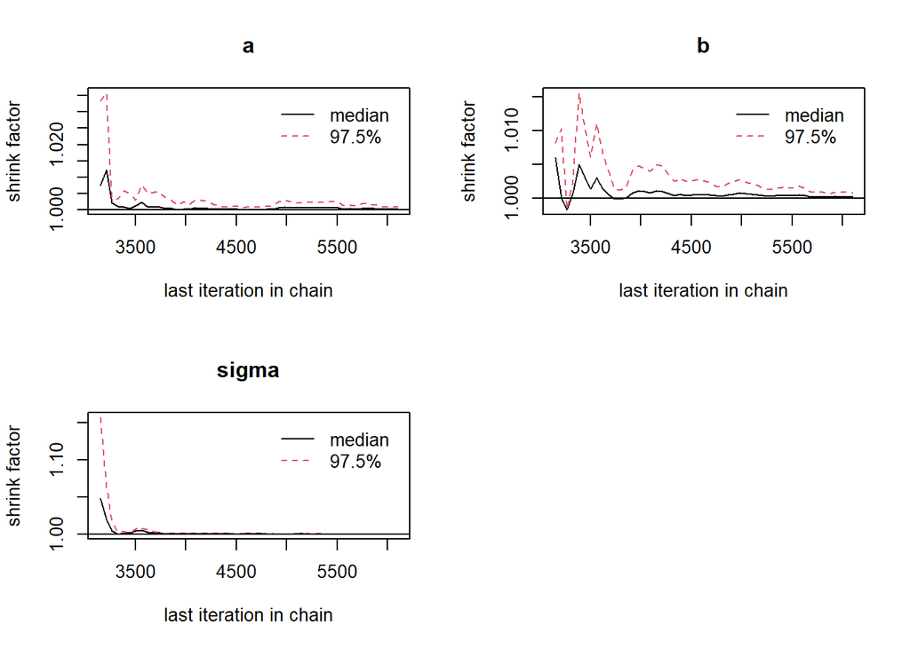

```r
gelman.plot(post)
```

Sprawdźmyy autokorelację.

```r
autocorr.diag(post)
```

```
##                   a            b        sigma
## Lag 0   1.000000000  1.000000000  1.000000000
## Lag 1   0.047124444  0.027115914  0.048634875
## Lag 5  -0.008058863  0.006086461 -0.015537595
## Lag 10 -0.011573650 -0.009345135 -0.009322869
## Lag 50  0.011069195 -0.008943446  0.008072007
```

Porównując z moim zabawkowym kodem z poprzedniej części widzimy, że autokorelacja praktycznie nie występuje.

Jak widzimy, JAGS poradził sobie dużo lepiej z regresją liniową. Ponadto jego składnia jest prosta. Dlatego do z niego będziemy korzystać w następnych częściach tutorialu.

# Bonus - diagramy Bayesowskie

Warto wspomnieć, że do wizualizacji modeli bayesowskich często używa się grafów (ja do ich budowy używam biblioteki *daft* w pythonie). W przypadku naszego modelu:

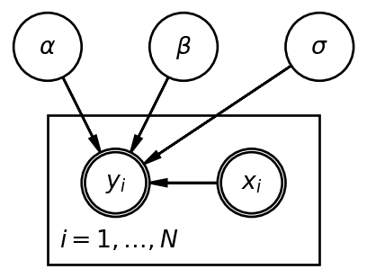

```python
import daft
import matplotlib.pyplot as plt

pgm = daft.PGM(observed_style="inner")

pgm.add_node("alpha", r"$\alpha$", 0.5, 2)
pgm.add_node("beta", r"$\beta$", 1.5, 2)
pgm.add_node("sigma", r"$\sigma$", 2.5, 2)
pgm.add_node("x", r"$x_i$", 2, 1, observed=True)
pgm.add_node("y", r"$y_i$", 1, 1, observed=True)

pgm.add_edge("alpha", "y")
pgm.add_edge("beta", "y")
pgm.add_edge("x", "y")
pgm.add_edge("sigma", "y")

pgm.add_plate([0.5, 0.5, 2, 1], label=r"$i = 1, \ldots, N$", shift=-0.1)

pgm.render()
plt.show()
```

Diagram pokazuje, że rozkład zmiennej $y_i$ definują 3 nieobserwowalne parametry (pojedyńcze okręgi) i jedna obserwowalna zmienna (dwuwarstwowy okrąg).

W przypadku modeli bayesowskich zapewno dosyć często będziecie się spotykać z takimi graficznymi opisami modeli.